# RPE Project Inclass Activities

Exploratory Data Analysis and Data Wrangling

Elijah Kates

IBM 3202, Cal Poly Pomona

2026-05-06

# Introduction

## Loading Libraries and Data

```r
library(tidyverse)
library(haven)    # for reading SPSS files
library(labelled)
library(sjPlot)
library(janitor)
library(dplyr)
library(gt)

theme_set(theme_minimal())
```

## Reading and Printing Data

```r
data <- read_sav("data/RPE - Combined-2019-12-19.sav")

data <- data |>
  clean_names()
```

## Data Structure and Summary

```r
str(data)
```

```
tibble [862 × 167] (S3: tbl_df/tbl/data.frame)
 $ subject               : num [1:862] 1 2 3 4 5 6 7 8 9 10 ...
  ..- attr(*, "format.spss")= chr "F8.0"
 $ per_survey            : num [1:862] 1 2 3 4 5 6 7 8 9 10 ...
  ..- attr(*, "format.spss")= chr "F8.0"
 $ survey                : dbl+lbl [1:862] 1, 1, 1, 1, 1, 1, 1, 1, 1, 1, 1, 1, 1, 1, 1, 1, 1, 1, ...
   ..@ label      : chr "Survey (1_W2011, 2_SP2011)"
   ..@ format.spss: chr "F8.0"
   ..@ labels     : Named num [1:2] 1 2
   .. ..- attr(*, "names")= chr [1:2] "Winter 2011" "Spring 2011"
 $ start_time            : POSIXct[1:862], format: "2011-03-15 16:20:59" "2011-03-12 17:27:00" ...
 $ end_time              : POSIXct[1:862], format: "2011-03-15 16:25:00" "2011-03-12 17:34:59" ...
 $ duration              : num [1:862] 4 8 5 6 3 2 6 3 7 6 ...
  ..- attr(*, "format.spss")= chr "F8.0"
 $ major_class           : dbl+lbl [1:862] 3, 5, 5, 5, 1, 1, 3, 5, 5, 3, 3, 5, 3, 3, 3, 3, 3, 3, ...
   ..@ label      : chr "Major Class (W2011_1-5, SP2011_6-13)"
   ..@ format.spss: chr "F8.0"
   ..@ labels     : Named num [1:13] 1 2 3 4 5 6 7 8 9 10 ...
   .. ..- attr(*, "names")= chr [1:13] "W2011-IBM301-01 (Dr. Hossain)" "W2011-IBM301-02 (Dr. Myers)" "W2011-IBM301-03 (Dr. Jung)" "W2011-IBM301-04 (Dr. Whitson)" ...
 $ incentive_prime       : dbl+lbl [1:862] 1, 2, 2, 2, 1, 2, 1, 2, 2, 1, 1, 2, 1, 1, 2, 2, 1, 1, ...
   ..@ label      : chr "Primary Incentive_1,2,3 (Req, Extra,No Credit)"
   ..@ format.spss: chr "F8.0"
   ..@ labels     : Named num [1:3] 1 2 3
   .. ..- attr(*, "names")= chr [1:3] "Required Course Credit" "Extra Credit" "No Credit Offered"
 $ major                 : dbl+lbl [1:862] NA, NA, NA, NA, NA, NA, NA, NA, NA, NA, NA, NA, NA, NA...
   ..@ label      : chr "Majors_1-10 (Ac_Ci_F_IB_Mg_Mk_T_E_HRT_Oth)"
   ..@ format.spss: chr "F8.0"
   ..@ labels     : Named num [1:10] 1 2 3 4 5 6 7 8 9 10
   .. ..- attr(*, "names")= chr [1:10] "Accounting" "Computer Information System" "Finance and Real Estate" "International Business" ...
 $ resch_covered         : dbl+lbl [1:862] 1, 2, 2, 1, 1, 1, 3, 1, 1, 1, 3, 4, 3, 1, 1, 1, 1, 1, ...
   ..@ label      : chr "Marketing research chapter covered and tested_ 1,2,3,4 (Y,N, NS,NA)"
   ..@ format.spss: chr "F8.0"
   ..@ labels     : Named num [1:4] 1 2 3 4
   .. ..- attr(*, "names")= chr [1:4] "Yes" "No" "Not Sure" "Not Applicable"
 $ validy_covered        : dbl+lbl [1:862] 1, 1, 2, 3, 1, 2, 1, 2, 1, 1, 1, 4, 1, 1, 1, 1, 1, 1, ...
   ..@ label      : chr "Research reliability and validity covered_1,2,3,4 (Y,N, NS,NA)"
   ..@ format.spss: chr "F8.0"
   ..@ labels     : Named num [1:4] 1 2 3 4
   .. ..- attr(*, "names")= chr [1:4] "Yes" "No" "Not Sure" "Not Applicable"
 $ grade                 : dbl+lbl [1:862] 2, 1, 1, 2, 3, 2, 1, 1, 1, 1, 2, 1, 3, 2, 3, 1, 1, 1, ...
```

[output cut: 427 more lines]

```
   ..@ labels       : Named num [1:7] 1 2 3 4 5 6 7
   .. ..- attr(*, "names")= chr [1:7] "Strongly disagree" "Disagree" "Somewhat disagree" "Neither disagree nor agree" ...
 $ sona_help_qamp_a_c    : dbl+lbl [1:862] NA, NA, NA, NA, NA, NA, NA, NA, NA, NA, NA, NA, NA, NA...
   ..@ label        : chr "Sona: Q&A Helpful_1-7 (Not at all helpful - NA)"
   ..@ format.spss  : chr "F8.2"
   ..@ display_width: int 19
   ..@ labels       : Named num [1:7] 1 2 3 4 5 6 7
   .. ..- attr(*, "names")= chr [1:7] "1- Not at all helpful" "2" "3" "4" ...
 $ sona_conv_app_c       : dbl+lbl [1:862] NA, NA, NA, NA, NA, NA, NA, NA, NA, NA, NA, NA, NA, NA...
   ..@ label        : chr "Sona:Convenient appointment 1-7 (Not at all - VM convenient)"
   ..@ format.spss  : chr "F8.2"
   ..@ display_width: int 17
   ..@ labels       : Named num [1:7] 1 2 3 4 5 6 7
   .. ..- attr(*, "names")= chr [1:7] "1 - Not convenient at all" "2" "3" "4" ...
  [list output truncated]
```

```r
summary(data)
```

```
    subject         per_survey         survey
 Min.   :   1.0   Min.   :  1.00   Min.   :1.000
 1st Qu.: 216.2   1st Qu.: 43.25   1st Qu.:2.000
 Median : 454.5   Median : 87.00   Median :4.000
 Mean   : 480.4   Mean   : 91.25   Mean   :3.761
 3rd Qu.: 738.5   3rd Qu.:133.00   3rd Qu.:5.000
 Max.   :1017.0   Max.   :250.00   Max.   :6.000

   start_time                     end_time                      duration
 Min.   :2011-03-12 15:04:00   Min.   :2011-03-12 15:11:00   Min.   : 2.00
 1st Qu.:2011-03-13 01:21:15   1st Qu.:2011-03-13 01:29:30   1st Qu.: 7.00
 Median :2011-03-15 14:28:00   Median :2011-03-15 14:32:00   Median :10.00
 Mean   :2011-04-17 12:53:53   Mean   :2011-04-17 13:02:34   Mean   :10.86
 3rd Qu.:2011-06-03 23:27:45   3rd Qu.:2011-06-03 23:38:45   3rd Qu.:13.00
 Max.   :2011-06-06 06:11:00   Max.   :2011-06-06 06:18:00   Max.   :66.00
 NA's   :566                   NA's   :566
  major_class     incentive_prime     major        resch_covered
 Min.   : 1.000   Min.   :1.000   Min.   : 1.000   Min.   :1.000
 1st Qu.: 3.000   1st Qu.:1.000   1st Qu.: 3.000   1st Qu.:1.000
 Median : 3.000   Median :2.000   Median : 5.000   Median :1.000
 Mean   : 4.805   Mean   :1.541   Mean   : 5.567   Mean   :1.506
 3rd Qu.: 5.000   3rd Qu.:2.000   3rd Qu.: 9.000   3rd Qu.:2.000
 Max.   :21.000   Max.   :3.000   Max.   :10.000   Max.   :4.000
                                  NA's   :172
 validy_covered      grade        like_ibm301   like_research   help_under_r_c
 Min.   :1.000   Min.   :1.000   Min.   :1.00   Min.   :1.000   Min.   :1.000
 1st Qu.:1.000   1st Qu.:1.000   1st Qu.:3.00   1st Qu.:3.000   1st Qu.:3.000
 Median :1.000   Median :2.000   Median :4.00   Median :4.000   Median :3.000
 Mean   :1.416   Mean   :1.964   Mean   :3.74   Mean   :3.753   Mean   :3.406
 3rd Qu.:1.000   3rd Qu.:2.000   3rd Qu.:4.00   3rd Qu.:4.000   3rd Qu.:4.000
 Max.   :4.000   Max.   :5.000   Max.   :6.00   Max.   :6.000   Max.   :6.000
                 NA's   :7
 help_know_g_r  help_under_m_c  credit_earned     n_studies      motive_part
 Min.   :1.00   Min.   :1.000   Min.   :0.000   Min.   :0.000   Min.   :1.00
 1st Qu.:3.00   1st Qu.:3.000   1st Qu.:1.000   1st Qu.:2.000   1st Qu.:2.00
 Median :3.00   Median :3.000   Median :2.000   Median :2.000   Median :2.00
 Mean   :3.42   Mean   :3.367   Mean   :2.521   Mean   :2.524   Mean   :2.37
 3rd Qu.:4.00   3rd Qu.:4.000   3rd Qu.:4.000   3rd Qu.:3.000   3rd Qu.:3.00
 Max.   :5.00   Max.   :5.000   Max.   :7.000   Max.   :5.000   Max.   :3.00
                                                NA's   :4       NA's   :2
```

[output cut: 273 more lines]

```
 Min.   :0.0000   Min.   :0.0000   Min.   :0.000       Min.   :0.0000
 1st Qu.:0.0000   1st Qu.:1.0000   1st Qu.:0.000       1st Qu.:0.0000
 Median :1.0000   Median :1.0000   Median :1.000       Median :0.0000
 Mean   :0.7471   Mean   :0.7854   Mean   :0.594       Mean   :0.4645
 3rd Qu.:1.0000   3rd Qu.:1.0000   3rd Qu.:1.000       3rd Qu.:1.0000
 Max.   :1.0000   Max.   :1.0000   Max.   :1.000       Max.   :1.0000
                                                       NA's   :3
 incentive_prime_2
 Min.   :0.0000
 1st Qu.:0.0000
 Median :1.0000
 Mean   :0.5355
 3rd Qu.:1.0000
 Max.   :1.0000
 NA's   :3
```

```r
#| label: variables-listing
glimpse(data)
```

```
Rows: 862
Columns: 167
$ subject                <dbl> 1, 2, 3, 4, 5, 6, 7, 8, 9, 10, 11, 12, 13, 14, …
$ per_survey             <dbl> 1, 2, 3, 4, 5, 6, 7, 8, 9, 10, 11, 12, 13, 14, …
$ survey                 <dbl+lbl> 1, 1, 1, 1, 1, 1, 1, 1, 1, 1, 1, 1, 1, 1, 1…
$ start_time             <dttm> 2011-03-15 16:20:59, 2011-03-12 17:27:00, 2011…
$ end_time               <dttm> 2011-03-15 16:25:00, 2011-03-12 17:34:59, 2011…
$ duration               <dbl> 4, 8, 5, 6, 3, 2, 6, 3, 7, 6, 7, 4, 7, 5, 4, 8,…
$ major_class            <dbl+lbl> 3, 5, 5, 5, 1, 1, 3, 5, 5, 3, 3, 5, 3, 3, 3…
$ incentive_prime        <dbl+lbl> 1, 2, 2, 2, 1, 2, 1, 2, 2, 1, 1, 2, 1, 1, 2…
$ major                  <dbl+lbl> NA, NA, NA, NA, NA, NA, NA, NA, NA, NA, NA,…
$ resch_covered          <dbl+lbl> 1, 2, 2, 1, 1, 1, 3, 1, 1, 1, 3, 4, 3, 1, 1…
$ validy_covered         <dbl+lbl> 1, 1, 2, 3, 1, 2, 1, 2, 1, 1, 1, 4, 1, 1, 1…
$ grade                  <dbl+lbl> 2, 1, 1, 2, 3, 2, 1, 1, 1, 1, 2, 1, 3, 2, 3…
$ like_ibm301            <dbl+lbl> 5, 3, 6, 2, 4, 2, 3, 5, 4, 3, 4, 6, 2, 2, 5…
```

[output cut: 154 more lines]

```r
# data dictionary
view_df(data)
```

Data frame: data

[output not shown]

[output cut: 137 more lines]

## Exploratory Data Analysis

**Tip**

In this section, we will explore data using the skills taught in the IBM 3202 course.

## Group Project Research Objective (Theme)

Impact of Sona system usability and technical factors on student research participation

## Research Question

How does the ease of use of the Sona system influence student attitudes toward research participation?

- Independent Variable
  - Ease of use of Sona system (at_sona_3)
  - Composite measure including enrollment ease, navigation ease, and system features
- Dependent Variable
  - Student attitude toward research participation (att_parti_res)
  - Composite measure based on perceptions of participation being good, positive, fun, and useful

## Data Preparation

```r
sona_data <- data %>%
  select(at_sona_3, att_parti_res)
#| label: Remove missing values
sona_data <- na.omit(sona_data)
```

```r
str(sona_data)
```

```
tibble [690 × 2] (S3: tbl_df/tbl/data.frame)
 $ at_sona_3    : num [1:690] 7 6.67 7 2.67 6 ...
  ..- attr(*, "label")= chr "Attitude toward Sona_3 - Avg (Enr-Nav-AutoFeat)"
  ..- attr(*, "format.spss")= chr "F8.2"
  ..- attr(*, "display_width")= int 11
 $ att_parti_res: num [1:690] 4 3.75 4.5 2.25 4.5 4 3.25 4.5 3 3.25 ...
  ..- attr(*, "label")= chr "*Attitude toward Participation in Research_Avg_4 items (At_Parti_good, posi, fun, useful)"
  ..- attr(*, "format.spss")= chr "F8.2"
  ..- attr(*, "display_width")= int 15
 - attr(*, "na.action")= 'omit' Named int [1:172] 1 2 3 4 5 6 7 8 9 10 ...
  ..- attr(*, "names")= chr [1:172] "1" "2" "3" "4" ...
```

```r
summary(sona_data)
```

```
   at_sona_3     att_parti_res
 Min.   :1.000   Min.   :1.000
 1st Qu.:5.667   1st Qu.:3.500
 Median :6.667   Median :4.000
 Mean   :6.116   Mean   :4.011
 3rd Qu.:7.000   3rd Qu.:4.500
 Max.   :7.000   Max.   :5.000
```

- After selecting the relevant variables, rows with missing values were removed, resulting in a final sample of 690 observations used for analysis.

## Participation Groups

```r
sona_data <- sona_data %>%
  mutate(
    participation_group = case_when(
      att_parti_res >= 4 ~ "High Participation Attitude",
      att_parti_res >= 3 ~ "Moderate Participation Attitude",
      TRUE ~ "Low Participation Attitude"
    )
  )

table(sona_data$participation_group)
```

```
    High Participation Attitude      Low Participation Attitude
                            448                              52
Moderate Participation Attitude
                            190
```

- Student attitudes toward participation were grouped into low, moderate, and high categories to better compare patterns in the data.

## Grouped Summary Statistics

```r
sona_summary <- sona_data %>%
  group_by(participation_group) %>%
  summarise(
    avg_sona_use = mean(at_sona_3, na.rm = TRUE),
    avg_participation = mean(att_parti_res, na.rm = TRUE),
    n = n()
  )

sona_summary
```

```
# A tibble: 3 × 4
  participation_group             avg_sona_use avg_participation     n
  <chr>                                  <dbl>             <dbl> <int>
1 High Participation Attitude             6.38              4.46   448
2 Low Participation Attitude              5.03              2.35    52
3 Moderate Participation Attitude         5.8               3.41   190
```

- Students with more positive attitudes toward research participation also tended to report higher ease of use with the Sona system.

# Visualization

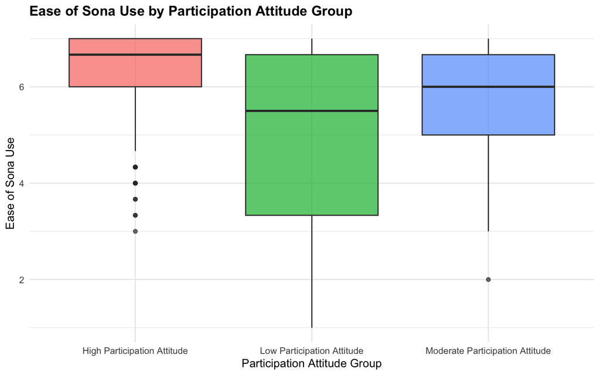

```r
ggplot(sona_data,
       aes(x = participation_group,
           y = at_sona_3,
           fill = participation_group)) +
  geom_boxplot(alpha = 0.7) +
  labs(
    title = "Ease of Sona Use by Participation Attitude Group",
    x = "Participation Attitude Group",
    y = "Ease of Sona Use"
  ) +
  theme_minimal() +
  theme(
    legend.position = "none",
    plot.title = element_text(face = "bold")
  )
```

- The visualization suggests that students with stronger participation attitudes generally reported higher ease of use scores for the Sona system.

# Analysis

```r
cor(sona_data$at_sona_3, sona_data$att_parti_res)
```

```
[1] 0.4205397
```

- A correlation analysis was run to see how ease of use relates to student attitudes.
- The correlation coefficient was r = 0.42, indicating a moderate positive relationship.